# VMIL 2021

# Ribbit

- Multiple implementations
  - C
  - JS
  - Python
  - Scheme
- AOT compiler : `rsc.scm` + library files
- Compiled code runs on the `rVM`

# Why Scheme?

- Small specification
- Extensible
- Compiled programs can be abstracted in few VM primitives
- However, Some non-trivial features:
  - Tail-Call optimizations
  - First-class continuations
  - Garbage Collection

# Runtime libraries

- Two flavors:
  - `min` supports necessary features
  - `max` supports most of R4RS procedures (no I/O)
- Full REPL implementation:
  - Implies some IO primitives

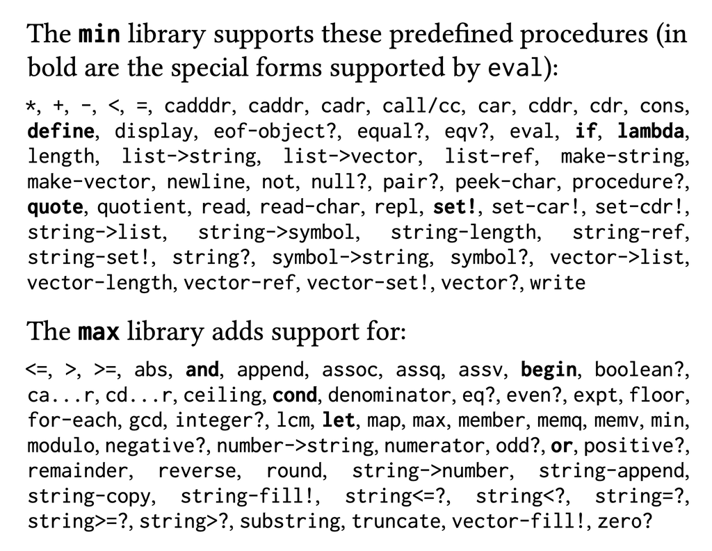

# Design: Basic Data Representation

- Data organized in a “rib”, a 3 field structure
- Fields can be:
  - A reference to a rib
  - A native integer
- Universal and versatile data structure:
  - Chainable through any field
  - Program source is a linked chain of ribs
  - Stack is also a linked chain of ribs
  - Complex chaining possible

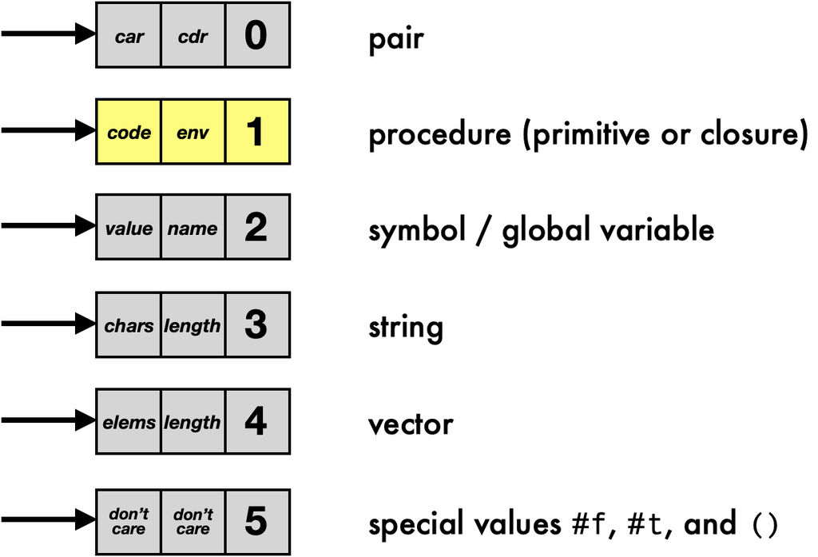

# Design: Code Representation

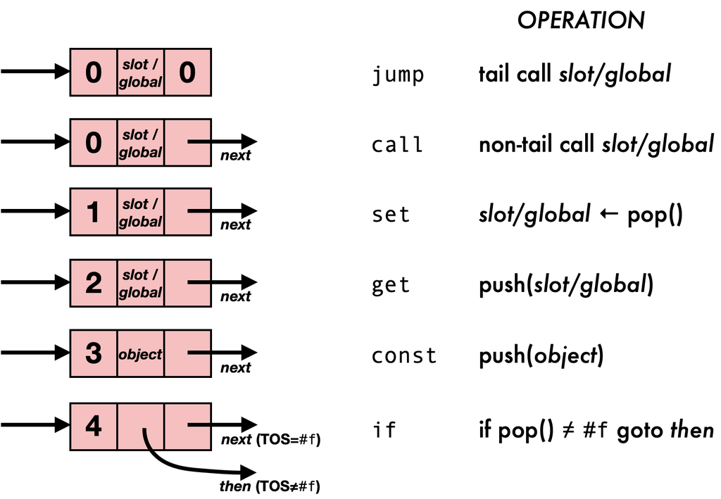

# Design: Garbage Collection

- Rely on host’s garbage collector if possible
- Otherwise, implementation of Cheney-style “Stop & Copy”
- Implemented in the C virtual machine
  - Requires a tagged representation of integers to distinguish with rib reference

# Design: Primitive Operations

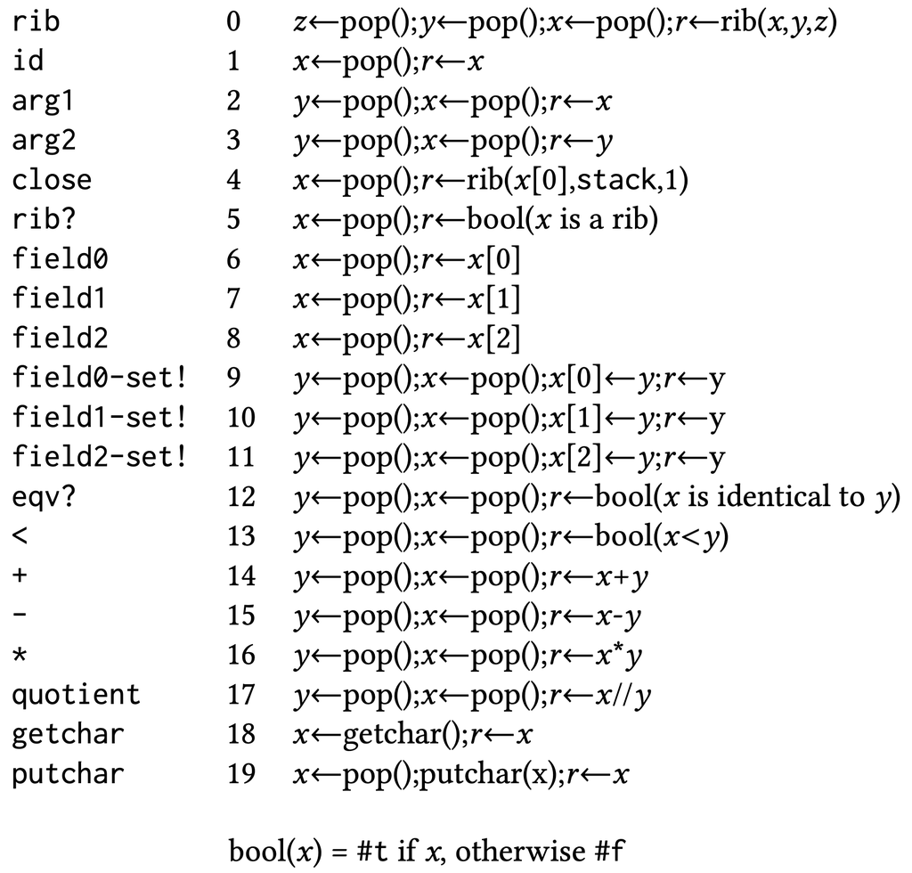

# Design: Running Factorial

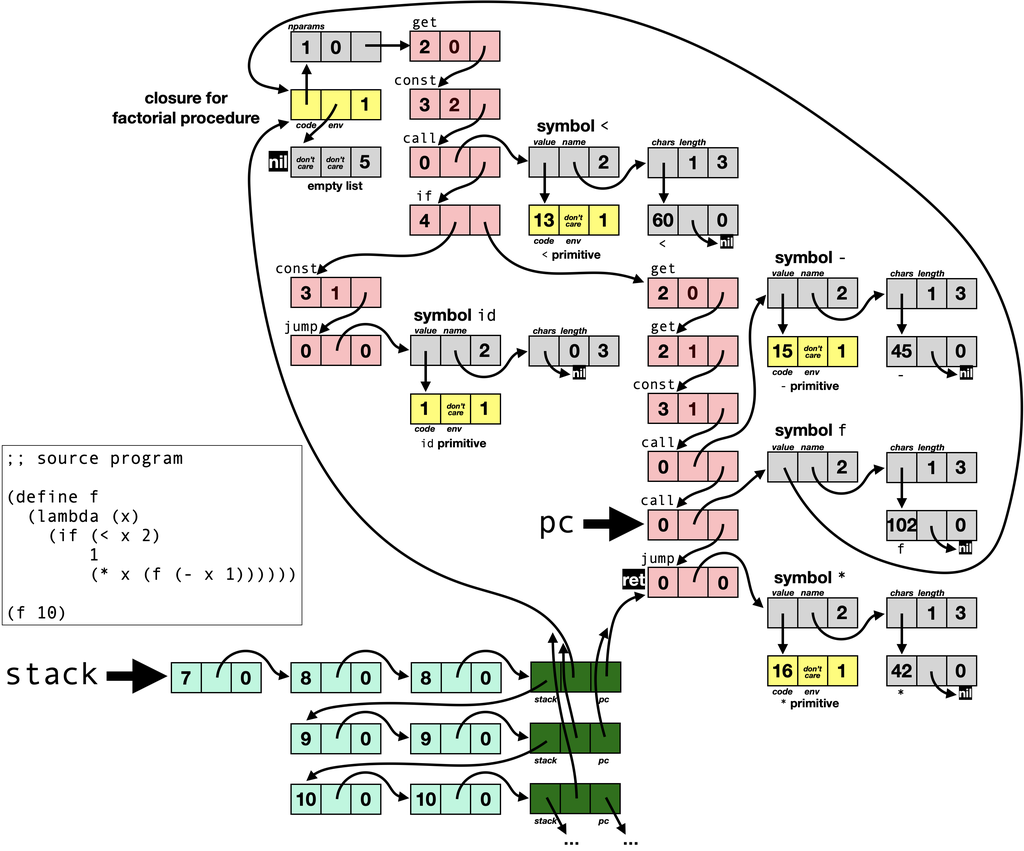

# Performance

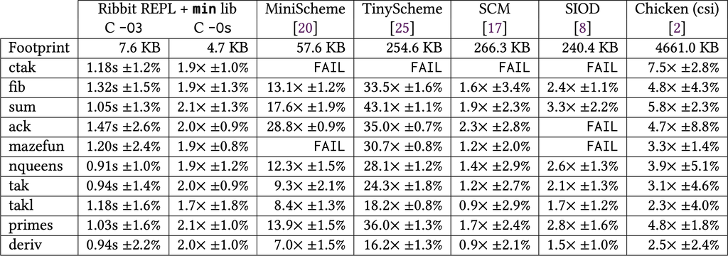

# Future Extensions

- Closure Space Safety
- Type Checking
- Easy to change program on the fly : Basic Block Versioning
- Customizable embedded Scheme system (selectable feature-set)

# Conclusion

- Full Paper: https://doi.org/10.1145/3486606.3486783
- Github link: https://github.com/udem-dlteam/ribbit
- This interactive slideshow within the Github repository